# Q & K Box 15.1

Wu et al. (2021) took soil samples at 300 sites near the Three Gorges Reservoir in China. Each site was classified into one of three categories of land use: orchard (n = 75), dry land (n = 98), and paddy field (n = 127). They also measured the concentrations of ten metals (Ca, Cd, Cr, Cu, Fe, Mg, Mn, Ni, Pb, and Zn; mg/kg) and five soil characteristics (pH, concentrations of N and P in mg/kg, and % of soil organic carbon [SOC] and K) for each site. Wu et al. (2021) did a PCA on the metals and used the components in further analyses. Using PCA, we will instead examine the pattern among sites and land use categories based on the metals and the other characteristics (15 variables in total).

The paper is [here](https://doi.org/10.1371/journal.pone.0254928)

Wu, W., Li, Y., Yan, M., Yang, L., Lei, J. & Liu, H. B. (2021). Surface soil metal elements variability affected by environmental and soil properties. *PLoS One*, 16, e0254928.

### Preliminaries

packages: vegan, Rmisc, lmodel2, pscych; ggvegan & ggfortify for graphics

```r
source("../R/libraries.R")   #This is the common library
```

[output not shown]

```r
library(vegan)
library(ggvegan)
library(ggfortify)
library(lmodel2)
library(psych)
```

```r
library(MultBiplotR)
# ggvegan is used for some graphics; it needs to be installed from github. Use the code in the next line to install it.
#remotes::install_github("gavinsimpson/ggvegan") #Use once to get ggvegan
devtools::source_url("https://raw.githubusercontent.com/mjkeough/mjkeough.github.io/refs/heads/main/R/appearance.R")  #Graphics tweaks
```

```
## ℹ SHA-1 hash of file is "a6df54e0f71bb238af60abd3d8ca755800be0aeb"
```

Run evplot function needed to draw broken stick graph

**Needs function from Legendre & Legendre book**

```r
source ('http://www.davidzeleny.net/anadat-r/doku.php/en:numecolr:evplot?do=export_code&codeblock=1')
```

Read in the data (wu.csv)

```r
wu <- read_csv("../data/wu.csv")
head(wu, 10)
```

| ca | cr | cu | fe | mn | pb | zn | cd | mg | ni | soc | ph | n | k | p | landuse | group |
| --- | --- | --- | --- | --- | --- | --- | --- | --- | --- | --- | --- | --- | --- | --- | --- | --- |
| 0.810 | 66.25 | 20.392 | 3.467 | 633.3 | 21.47 | 68.85 | 0.175 | 1.400 | 25.94 | 0.590 | 6.82 | 710.7 | 2.122 | 597.06 | Dryland | 1 |
| 0.466 | 43.78 | 10.294 | 2.044 | 228.9 | 22.45 | 36.47 | 0.134 | 0.482 | 13.30 | 0.840 | 6.17 | 744.7 | 1.518 | 304.95 | Paddy | 2 |
| 0.932 | 69.99 | 25.588 | 3.777 | 569.0 | 25.59 | 78.13 | 0.227 | 1.590 | 31.32 | 0.980 | 6.13 | 1122.7 | 2.610 | 701.92 | Dryland | 1 |
| 0.810 | 60.63 | 19.902 | 3.542 | 546.1 | 25.29 | 67.55 | 0.175 | 1.232 | 26.23 | 0.977 | 6.33 | 1025.9 | 2.163 | 481.50 | Orchard | 3 |
| 0.322 | 46.49 | 7.441 | 2.087 | 238.7 | 20.88 | 28.85 | 0.096 | 0.403 | 12.17 | 0.630 | 5.41 | 647.9 | 1.383 | 374.50 | Paddy | 2 |
| 0.910 | 76.13 | 24.314 | 4.045 | 832.8 | 24.12 | 77.96 | 0.185 | 1.602 | 33.02 | 0.582 | 6.92 | 657.1 | 2.413 | 682.66 | Paddy | 2 |
| 1.088 | 73.22 | 28.529 | 3.938 | 680.2 | 26.08 | 94.58 | 0.350 | 1.669 | 31.04 | 0.870 | 6.82 | 832.2 | 2.288 | 1011.15 | Dryland | 1 |
| 1.199 | 66.77 | 32.157 | 3.552 | 735.8 | 25.10 | 145.42 | 0.258 | 1.490 | 30.75 | 1.170 | 7.34 | 1346.2 | 2.475 | 2474.91 | Dryland | 1 |
| 0.400 | 44.51 | 7.794 | 1.755 | 164.6 | 20.88 | 28.92 | 0.134 | 0.381 | 10.00 | 0.860 | 5.86 | 802.4 | 1.622 | 291.04 | Paddy | 2 |
| 0.855 | 69.68 | 25.196 | 3.638 | 737.9 | 25.69 | 77.45 | 0.340 | 1.299 | 30.19 | 0.874 | 6.67 | 1015.6 | 2.298 | 892.38 | Dryland | 1 |

Quick data summary

```r
wu %>%
  summarise_all(list(Mean=mean, SD=sd, Max=max,Min=min))
```

| ca_Mean | cr_Mean | cu_Mean | fe_Mean | mn_Mean | pb_Mean | zn_Mean | cd_Mean | mg_Mean | ni_Mean | soc_Mean | ph_Mean | n_Mean | k_Mean | p_Mean | landuse_Mean | group_Mean | ca_SD | cr_SD | cu_SD | fe_SD | mn_SD | pb_SD | zn_SD | cd_SD | mg_SD | ni_SD | soc_SD | ph_SD | n_SD | … |
| --- | --- | --- | --- | --- | --- | --- | --- | --- | --- | --- | --- | --- | --- | --- | --- | --- | --- | --- | --- | --- | --- | --- | --- | --- | --- | --- | --- | --- | --- | --- |
| 0.7478733 | 64.38747 | 20.82442 | 3.23216 | 527.0303 | 25.52547 | 68.22283 | 0.22119 | 1.123737 | 25.79337 | 0.7868033 | 6.255733 | 888.3353 | 2.06397 | 627.6393 | NA | 1.923333 | 0.2895654 | 10.82058 | 5.882029 | 0.6651046 | 198.1942 | 2.308032 | 18.21474 | 0.06923843 | 0.4167136 | 7.629094 | 0.2087328 | 0.8268301 | 243.6481 | … |

### Diagnostic checks

Correlation and scatterplot matrices

```r
wu.cor<-cor(wu[,c('ca','cd','cr','cu','fe','mg','mn','ni','pb','zn','ph','soc','n','p','k')])
options(digits = 2)
wu.cor
```

```
##         ca   cd    cr     cu    fe     mg    mn    ni    pb    zn     ph    soc
## ca   1.000 0.41 0.503  0.670  0.69  0.809  0.72  0.68 0.200 0.737  0.686 -0.242
## cd   0.414 1.00 0.483  0.515  0.46  0.489  0.37  0.51 0.487 0.624  0.324  0.246
## cr   0.503 0.48 1.000  0.843  0.87  0.787  0.59  0.90 0.646 0.763  0.306  0.024
## cu   0.670 0.52 0.843  1.000  0.90  0.882  0.72  0.89 0.626 0.893  0.346 -0.057
## fe   0.691 0.46 0.869  0.904  1.00  0.918  0.78  0.93 0.631 0.878  0.347 -0.111
## mg   0.809 0.49 0.787  0.882  0.92  1.000  0.79  0.92 0.470 0.887  0.477 -0.174
## mn   0.722 0.37 0.590  0.724  0.78  0.794  1.00  0.72 0.338 0.727  0.383 -0.340
## ni   0.677 0.51 0.897  0.888  0.93  0.917  0.72  1.00 0.608 0.852  0.434 -0.103
## pb   0.200 0.49 0.646  0.626  0.63  0.470  0.34  0.61 1.000 0.589  0.024  0.311
## zn   0.737 0.62 0.763  0.893  0.88  0.887  0.73  0.85 0.589 1.000  0.393  0.013
## ph   0.686 0.32 0.306  0.346  0.35  0.477  0.38  0.43 0.024 0.393  1.000 -0.098
## soc -0.242 0.25 0.024 -0.057 -0.11 -0.174 -0.34 -0.10 0.311 0.013 -0.098  1.000
## n   -0.074 0.43 0.250  0.175  0.15  0.075 -0.18  0.17 0.500 0.242 -0.041  0.722
## p    0.473 0.30 0.252  0.466  0.36  0.425  0.40  0.32 0.202 0.559  0.148 -0.042
## k    0.712 0.48 0.735  0.813  0.84  0.919  0.73  0.87 0.494 0.841  0.449 -0.131
##          n      p      k
## ca  -0.074  0.473  0.712
## cd   0.426  0.297  0.481
## cr   0.250  0.252  0.735
## cu   0.175  0.466  0.813
## fe   0.151  0.363  0.844
## mg   0.075  0.425  0.919
## mn  -0.184  0.398  0.726
## ni   0.168  0.315  0.869
## pb   0.500  0.202  0.494
## zn   0.242  0.559  0.841
## ph  -0.041  0.148  0.449
## soc  0.722 -0.042 -0.131
## n    1.000  0.039  0.088
## p    0.039  1.000  0.409
## k    0.088  0.409  1.000
```

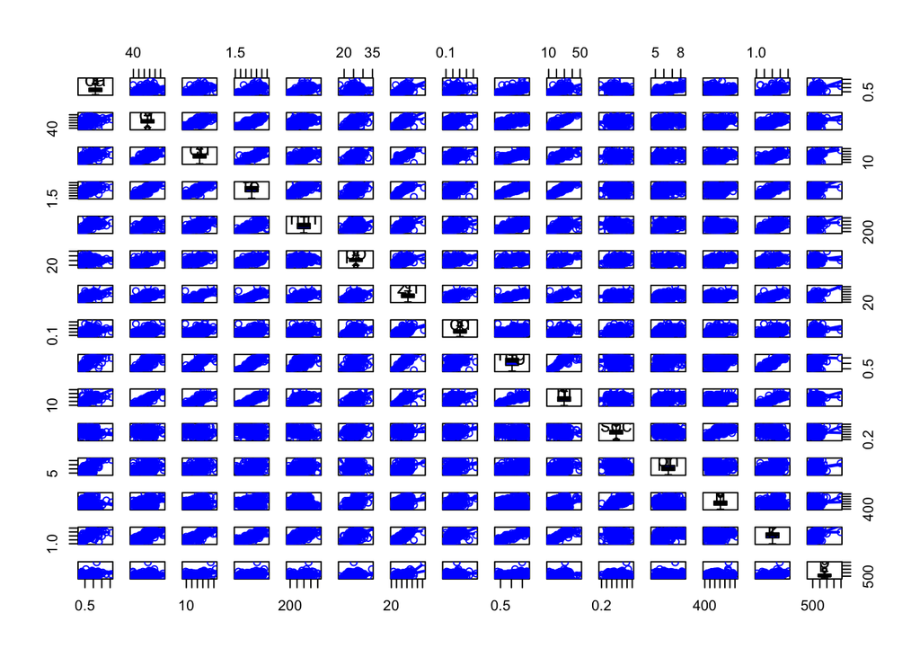

```r
scatterplotMatrix(~ca+cr+cu+fe+mn+pb+zn+cd+mg+ni+soc+ph+n+k+p,data=wu,diagonal=list(method='boxplot'))
```

### Plot component 1 using RMA regression

```r
wu1.rma <- lmodel2(cu~mn, data=wu)
```

```
## RMA was not requested: it will not be computed.
```

```
## No permutation test will be performed
```

```r
print(wu1.rma)
```

```
##
## Model II regression
##
## Call: lmodel2(formula = cu ~ mn, data = wu)
##
## n = 300   r = 0.72   r-square = 0.52
## Parametric P-values:   2-tailed = 5.4e-50    1-tailed = 2.7e-50
## Angle between the two OLS regression lines = 1.1 degrees
##
## Regression results
##   Method Intercept Slope Angle (degrees) P-perm (1-tailed)
## 1    OLS       9.5 0.021             1.2                NA
## 2     MA       9.5 0.021             1.2                NA
## 3    SMA       5.2 0.030             1.7                NA
##
## Confidence intervals
##   Method 2.5%-Intercept 97.5%-Intercept 2.5%-Slope 97.5%-Slope
## 1    OLS            8.2            10.8      0.019       0.024
## 2     MA            8.3            10.7      0.019       0.024
## 3    SMA            3.9             6.4      0.027       0.032
##
## Eigenvalues: 39299 16
##
## H statistic used for computing C.I. of MA: 5.4e-06
```

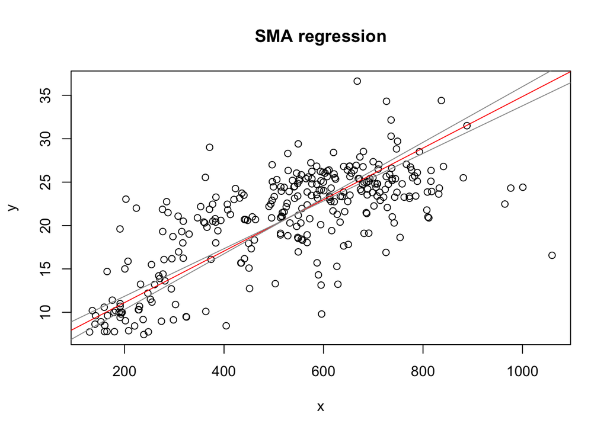

```r
plot(wu1.rma, method="SMA")
```

Check factorability of correlation matrix with Bartlett and KMO tests

```r
cortest.bartlett(wu.cor, n=300)
```

```
## $chisq
## [1] 5543
##
## $p.value
## [1] 0
##
## $df
## [1] 105
```

```r
KMO(wu.cor)
```

```
## Kaiser-Meyer-Olkin factor adequacy
## Call: KMO(r = wu.cor)
## Overall MSA =  0.9
## MSA for each item =
##   ca   cd   cr   cu   fe   mg   mn   ni   pb   zn   ph  soc    n    p    k
## 0.87 0.89 0.91 0.96 0.91 0.90 0.95 0.93 0.88 0.93 0.76 0.68 0.69 0.84 0.93
```

## Do PCA on correlation matrix; get summary with scaling=2

Scaling=2 is the rda default: angles between variables match their correlations)

### Get eigenvalues

```r
wu1.rda <- rda(wu[,c('ca','cd','cr','cu','fe','mg','mn','ni','pb','zn','ph','soc','n','p','k')],scale=TRUE)
summary(wu1.rda)
```

```
##
## Call:
## rda(X = wu[, c("ca", "cd", "cr", "cu", "fe", "mg", "mn", "ni",      "pb", "zn", "ph", "soc", "n", "p", "k")], scale = TRUE)
##
## Partitioning of correlations:
##               Inertia Proportion
## Total              15          1
## Unconstrained      15          1
##
## Eigenvalues, and their contribution to the correlations
##
## Importance of components:
##                         PC1   PC2    PC3    PC4    PC5    PC6    PC7    PC8
## Eigenvalue            8.569 2.372 1.0935 0.9056 0.4962 0.3174 0.3029 0.2471
## Proportion Explained  0.571 0.158 0.0729 0.0604 0.0331 0.0212 0.0202 0.0165
## Cumulative Proportion 0.571 0.729 0.8023 0.8626 0.8957 0.9169 0.9371 0.9535
##                          PC9   PC10    PC11    PC12   PC13    PC14    PC15
## Eigenvalue            0.2141 0.1577 0.10979 0.07509 0.0584 0.04970 0.03206
## Proportion Explained  0.0143 0.0105 0.00732 0.00501 0.0039 0.00331 0.00214
## Cumulative Proportion 0.9678 0.9783 0.98565 0.99065 0.9945 0.99786 1.00000
```

```r
wu1.eig <- wu1.rda$CA$eig
wu1.eig
```

```
##   PC1   PC2   PC3   PC4   PC5   PC6   PC7   PC8   PC9  PC10  PC11  PC12  PC13
## 8.569 2.372 1.094 0.906 0.496 0.317 0.303 0.247 0.214 0.158 0.110 0.075 0.058
##  PC14  PC15
## 0.050 0.032
```

### Get scree and broken stick plots

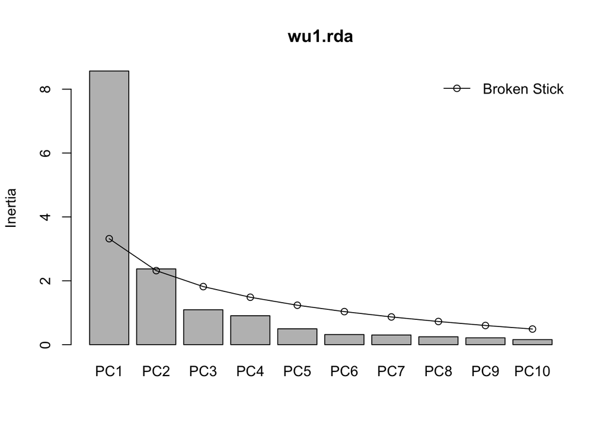

```r
screeplot(wu1.rda,bstick=TRUE, bst.col="black",xlab = "Component", ylab = "Inertia",)
```

```r
bstick(wu1.rda)
```

```
##   PC1   PC2   PC3   PC4   PC5   PC6   PC7   PC8   PC9  PC10  PC11  PC12  PC13
## 3.318 2.318 1.818 1.485 1.235 1.035 0.868 0.725 0.600 0.489 0.389 0.298 0.215
##  PC14  PC15
## 0.138 0.067
```

#### Alternative run evplot function to draw broken stick graph

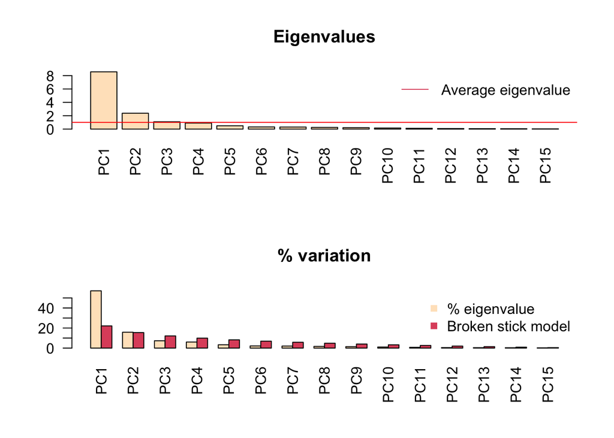

```r
evplot(wu1.eig)
```